# Summary

## Controll problem

Given a plant $\operatorname{f}: (x, u, n) \mapsto y$ where $x$ is the state, $u$ the controll input, $n$ modells external disturbances and $y$ is the observed output, we strive to find $u^* = \operatorname{argmin} \operatorname{d}(y_d, y)$ where $\operatorname{d}(., y_d)$ is an appropriate distance measure between measured output $y$ and desired output $y_d$.

## Regression

In regression we use samples $(x_i, y_i)$ where the Index $i$ indicates membership in a training set $\mathcal{I}$ to find a mapping $\hat{y}: \mathcal{X} \to \mathcal{Y}$ such that $\operatorname{d}(\hat{y}(x), y) < \epsilon \; x \notin \mathcal{I}$

```python
from _notebook import _input, _l
```

```python
_l('140521210549')
```

## State of the art

> Proceedings of the 2007 IEEE International Symposium on Computational Intelligence in Robotics and Automation Jacksonville, FL, USA, June 20-23, 2007 Local Online Support Vector Regression for Learning Control Younggeun Choi, Shin-Young Cheong, and Nicolas Schweighofer

propose to use a composite controll signal $u = u_{\mathrm{fb}} + u_{\mathrm{ff}}$ where $u_{\mathrm{ff}}$ is obtained from local online support vector regression and $u_{\mathrm{fb}}$ from a convential $PD$ controller for controll of an roboter arm.

However references cited in this paper such as

```python
_l('140520074532')
```

> On-line Support Vector Machines for Function Approximation Mario Martin email: mmartin@lsi.upc.es Software Department, Universitat Polit`cnica de Catalunya, Jordi Girona 1-3, Campus Nord, C6. 08034 Barcelona, Catalonia, Spain.

suggest that the method used is scalar valued i.e. $(.) : \mathbb{R}^d \to \mathbb{R}$ and thus several regression processes need to be running in parallel.

## Idea

This evokes the question if a inherently vector valued regression $(.) : \mathbb{R}^d \to \mathbb{R}^e$ might do better both with respect to computational effort and prediction quality by exploiting structural properties and correlations in the data more efficiently.

## A simple example

To gain some insight I would propose to look at a simple example in $(.) \mathbb{R} \to \mathbb{R}^2$

Let $\operatorname{s}(t)^T = t [cos(t), sin(t)] =: [x(t), y(t)]$

```python
from matplotlib.pyplot import scatter
from numpy import sin
from numpy import cos
from numpy import pi
from numpy import linspace
from matplotlib.pyplot import axis
```

```python
%matplotlib inline
```

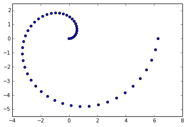

```python
t = linspace(0, 2 * pi, num=50)
scatter(t * cos(t), t * sin(t))
l = axis('equal')
```

Assuming we can find a vector valued regressions $\hat{s}(t): \mathbb{R} \to \mathbb{R}^2$ as well as $\hat{x}(t): \mathbb{R} \to \mathbb{R}$ $\hat{y}(t): \mathbb{R} \to \mathbb{R}$ where the latter may be found using the implementation given by

```python
_l('140522003148')
```

> Online Support Vector Regression Francesco Parrella A Thesis presented for the degree of Information Science Department of Information Science University of Genoa Italy June 2007

it would be interesting to evaluate $\operatorname{d}(\hat{s}(t), s(t) \leftrightarrow d([\hat{x}, \hat{y}]^T, s(t))$